# Analysis of Variance (ANOVA)

Numerical vs. categorical

[Dr. Peng Zhao](https://connect.xjtlu.edu.cn/user/pengzhao) (✉ peng.zhao@xjtlu.edu.cn)

Department of Health and Environmental Sciences  
Xi’an Jiaotong-Liverpool University

# 1 Learning objectives

In this lecture, you will

1. Understand the concept of the analysis of variance (ANOVA), and
2. Carry out one-way and two-way ANOVA for answering scientific questions.

# 2 Revisit the t-test

Example: Rats on diets

A biologist studies the weight gain of male lab rats on diets over a 4-week period. Three different diets are applied. The results are shown in the following table.

```r
dtf <- data.frame(diet1 = c(90, 95, 100),
                  diet2 = c(120, 125, 130),
                  diet3 = c(125, 130, 135))
```

| diet1 | diet2 | diet3 |
| --- | --- | --- |
| 90 | 120 | 125 |
| 95 | 125 | 130 |
| 100 | 130 | 135 |

Weight gain (gram) of male lab rats

- Are the weight gains of the three treatments are all equal?
- In another word, do the diets have influence on the weight gain?

If we do the $t$-test between each two treatments…

```r
dtt <- data.frame(Number_of_Samples = 2:10)
dtt$Number_of_Tests <- choose(dtt$Number_of_Samples, 2)
dtt$alpha_overall <- round(1 - (1 - 0.05)^dtt$Number_of_Tests, 2)
```

| Number_of_Samples | Number_of_Tests | alpha_overall |
| --- | --- | --- |
| 2 | 1 | 0.05 |
| 3 | 3 | 0.14 |
| 4 | 6 | 0.26 |
| 5 | 10 | 0.40 |
| 6 | 15 | 0.54 |
| 7 | 21 | 0.66 |
| 8 | 28 | 0.76 |
| 9 | 36 | 0.84 |
| 10 | 45 | 0.90 |

The increasing number of samples and the probability that at least one of the $t$-tests results in a significant difference

Instead of $t$-test for testing the means, we can transform the data as:

```r
dtf2 <- stack(dtf)
names(dtf2) <- c("wg", "diet")
```

| wg | diet |
| --- | --- |
| 90 | diet1 |
| 95 | diet1 |
| 100 | diet1 |
| 120 | diet2 |
| 125 | diet2 |
| 130 | diet2 |
| 125 | diet3 |
| 130 | diet3 |
| 135 | diet3 |

and analyse the relationship between the weight gain (numerical variable) of the diet treatments (categorical variable).

# 3 One-way ANOVA

**Analysis of variance (ANOVA):**

One of the most widely used statistical techniques. The test partitions the total variation present in a set of data into two or more components. Associated with each of these components is a specific source of variation, so that it is possible to ascertain the contributions of each of these sources to the total variation.

**One-way ANOVA:**

A test that concerns only one independent variable ($x$), which is called a factor and has multiple levels (settings, groups).

1. Hypotheses:
   - $H_0: \mu _1 = \mu _2 = \mu _3 = ... = \mu_k$
   - $H_1$: at least one mean is different from others
   - Reject $H_0$? Given $\alpha$.
2. Collect data. Suppose we have $k$ samples. The $i$-th sample has $n_i$ observations.

A data set which has only one independent variable with of multiple levels

|  | Level 1 | Level 2 | Level 3 | … | Level $k$ |
| --- | --- | --- | --- | --- | --- |
|  | $x_{1,1}$ | $x_{2, 1}$ | $x_{3,1}$ | … | $x_{k,1}$ |
|  | $x_{1,2}$ | $x_{2,2}$ | $x_{3,2}$ | … | $x_{k,2}$ |
|  | $x_{1,3}$ | $x_{2, 3}$ | $x_{3,3}$ | … | $x_{k, 3}$ |
|  | . | . | . | . | . |
|  | . | $x_{2, n_2}$ | . | . | . |
|  | . |  | $x_{3,n_3}$ | . | . |
|  | $x_{1, n_1}$ |  |  | … | $x_{k, n_k}$ |
| Mean | $\bar x_1$ | $\bar x_2$ | $\bar x_3$ |  | $\bar x_k$ |

3. Calculate a test statistic: $F$-test.

The Entries of One-Way ANOVA Table

| Source | $df$ | $SS$ | $MS$ | $F$ |
| --- | --- | --- | --- | --- |
| Within samples | $df_W = n - k$ | $SS_W = \sum_{i=1}^{k} \sum_{j=1}^{n_i}(x_{ij}-\bar x_i)^2$ | $MS_W = \frac{SS_W}{df_W}$ | $F = \frac{MS_B}{MS_W}$ |
| Between samples | $df_B = k - 1$ | $SS_B = \sum_{i = 1}^k n_i(\bar x_i - \bar x)^2$ | $MS_B = \frac {SS_B}{df_B}$ |  |
| Total | $df_T = n - 1$ | $SS_T = \sum_{i = 1}^k \sum _{j=1}^{n_i} (x_{ij}-\bar x) ^2$ | $MS_T = \frac{SS_T}{df_T}$ |  |

**$n$**

The total number of the observations. $n = \sum n_i$

**$x_{ij}$**

The $j$-th observation in the $i$-th sample

**$\bar x$**

Overall/grand mean of all the observations. $\bar x = \frac{\sum x_{ij}}{n}$

**$MS$**

Mean of squared deviation from the mean

**$SS$**

Sum of squared deviation from the mean

**$df$**

degrees of freedom

If $H_0$ is true, then any difference you see between the $k$ samples are due to chance, i.e. $\sigma^2_\mathrm {between} = \sigma^2_\mathrm {withiin} = \sigma^2_\mathrm {total}$, i.e. $MS_B = MS_T = MS_W$. ==> $F$-test.

From the previous table, we can get:

$$df_T = df_W+ df_B$$

$$SS_T = SS_W + SS_B$$

which can be used for double-check.

4. Decision. Reject or not reject $H_0$.
5. Conclusion. Whether the categorical variable has effect on the numerical variable.

Example: Rats on diets

1. Hypotheses and question:
   - $H_0: \mu _1 = \mu _2 = \mu _3$
   - $H_1$: at least one mean is different from others
   - Reject $H_0$?
2. Collect data:
3. Calculate a test statistics: $F$ test.

*Action*: Fill in the ANOVA table.

The ANOVA table for the weight gain experiment

| Source | $df$ | $SS$ | $MS$ | $F$ |
| --- | --- | --- | --- | --- |
| Within samples |  |  |  |  |
| Between samples |  |  |  |  |
| Total |  |  |  |  |

```r
# df
(k <- ncol(dtf))
(n <- length(unlist(dtf)))
(dfW <- n - k)
(dfB <- k - 1)
(dfT <- n-1)

# mean
(xbar <- mean(unlist(dtf)))
(xibar <- colMeans(dtf))

# SS
(SSW1 <- sum((dtf$diet1 - xibar[1]) ^ 2))
(SSW2 <- sum((dtf$diet2 - xibar[2]) ^ 2))
(SSW3 <- sum((dtf$diet3 - xibar[3]) ^ 2))
(SSW <- SSW1 + SSW2 + SSW3)
(SSB1 <- length(dtf$diet1) * (xibar[1] - xbar) ^ 2)
(SSB2 <- length(dtf$diet2) * (xibar[2] - xbar) ^ 2)
(SSB3 <- length(dtf$diet3) * (xibar[3] - xbar) ^ 2)
(SSB <- SSB1 + SSB2 + SSB3)

# Double check
(SST <- sum((unlist(dtf) - xbar) ^ 2))
SSW + SSB

SSB/SST # Correlation ratio

# F
(MSW <- SSW / dfW)
(MSB <- SSB / dfB)
(F_score <- MSB / MSW)
(F_critical <- qf(0.95, df1 = dfB, df2 = dfW))
pf(F_score, df1 = dfB, df2 = dfW, lower.tail = FALSE)
```

Mean and within-/between-samples sum of squares

|  | Diet 1 | Diet2 | Diet3 | Total |
| --- | --- | --- | --- | --- |
|  | 90 | 120 | 125 |  |
|  | 95 | 125 | 130 |  |
|  | 100 | 130 | 135 |  |
| $\bar x_i$ | 95 | 125 | 130 |  |
| $SS_W$ | 50 | 50 | 50 | 150 |
| $SS_B$ | 1408.3333333 | 208.3333333 | 533.3333333 | 2150 |

The ANOVA table for the weight gain experiment

| Source | $df$ | $SS$ | $MS$ | $F$ |
| --- | --- | --- | --- | --- |
| *W*ithin samples | 6 | 150 | 25 | 43 |
| *B*etween samples | 2 | 2150 | 1075 |  |
| *T*otal |  | 2300 |  |  |

4. Decision.

Since the F value is 43, which exceeds the critical value of 5.1432528 at the significance level of $\alpha = 0.05$, we can reject $H_0$.

One step:

```r
wg_aov <- aov(wg ~ diet, data = dtf2)
summary(wg_aov)
```

```
            Df Sum Sq Mean Sq F value   Pr(>F)
diet         2   2150    1075      43 0.000277 ***
Residuals    6    150      25
---
Signif. codes:  0 '***' 0.001 '**' 0.01 '*' 0.05 '.' 0.1 ' ' 1
```

5. Conclusion.

There is a significant effect of diet on the weight again of male laboratory rats.

The connection between ANOVA and t-test:

```r
dtf3 <- dtf2[1:6, ]
t.test(wg~diet, dtf3)
summary(aov(wg~diet, dtf3))
```

[output not shown]

# 4 Understand ANOVA

## 4.1 The model

$$x_{i j}=\mu+\tau_{j}+\epsilon_{i j} ; \quad i=1,2, \ldots, n_{j} ; \quad j=1,2, \ldots, k$$

**$\mu$**

The grand mean. The mean of all $k$ population means.

**$\tau_{j}$**

The treatment effect. The difference between the mean of the *j*-th population and the grand mean ($\bar x_j - \mu$).

**$\epsilon_{i j}$**

The error term. The amount by which an individual measurement differs from the mean of the population to which it belongs ($x_{ij} - \bar x_j$).

- $H_{0}: \mu_{1}=\mu_{2}=\cdots=\mu_{k}$
- $H_{A}:$ not all $\mu_{k}$ are equal

## 4.2 Assumptions

- The $k$ sets of observed data constitute $k$ independent random samples from the respective populations.
- Each of the populations from which the samples come is normally distributed with mean $\mu_{j}$ and variance $\sigma_{j}^{2}$.
- Each of the populations has the same variance. That is, $\sigma_{1}^{2}=\sigma_{2}^{2}=\cdots=\sigma_{k}^{2}=\sigma^{2},$ the common variance.
- The $\tau_{j}$ are unknown constants and $\sum \tau_{j}=0$ since the sum of all deviations of the $\mu_{j}$ from their mean, $\mu,$ is zero.
- The $\epsilon_{i j}$ have a mean of $0,$ since the mean of $x_{i j}$ is $\mu_{j}$
- The $\epsilon_{i j}$ have a variance equal to the variance of the $x_{i j},$ since the $\epsilon_{i j}$ and $x_{i j}$ differ only by a constant; that is, the error variance is equal to $\sigma^{2},$ the common variance specified in the assumption above.
- The $\epsilon_{i j}$ are normally (and independently) distributed.

## 4.3 Estimating the statistics

The population variance $\sigma^{2}$ may be estimated in two ways:

1. $\sigma ^2 = MS_W = \frac{SS_W}{df_W}$
2. $\sigma ^2 = MS_B = \frac{SS_B}{df_B}$

Compare the two estimates of the population variance: $F_\mathrm {score} = MSB/MSW$.

- The numerator df: $k − 1$.
- The denominator df: $n - k$.

# 5 Repeated measures

Repeated measures (matched samples, randomized blocks, within subjects):

- $k$ samples.
- Each sample has $n$ observations.

A data set which has repeated measures with only one independent variable with of multiple levels

| ID | Level 1 | Level 2 | Level 3 | … | Level $k$ |
| --- | --- | --- | --- | --- | --- |
| 1 | $x_{1,1}$ | $x_{2, 1}$ | $x_{3,1}$ | … | $x_{k,1}$ |
| 2 | $x_{1,2}$ | $x_{2,2}$ | $x_{3,2}$ | … | $x_{k,2}$ |
| 3 | $x_{1,3}$ | $x_{2, 3}$ | $x_{3,3}$ | … | $x_{k, 3}$ |
| . | . | . | . | . | . |
| n | $x_{1, n}$ | $x_{2, n}$ | $x_{3, n}$. | … | $x_{k, n}$ |

The Entries of One-Way ANOVA Table for Repeated Measures

| Source | $df$ | $SS$ | $MS$ | $F$ |
| --- | --- | --- | --- | --- |
| Within samples | $df_W = nk - k$ | $SS_W = \sum_{i=1}^{k} \sum_{j=1}^{n}(x_{ij}-\bar x_i)^2$ | $MS_W = \frac{SS_W}{df_W}$ | $F = \frac{MS_B}{MS_{Wcorr}}$ |
| Between samples | $df_B = k - 1$ | $SS_B = \sum_{i = 1}^k n(\bar x_i - \bar x)^2$ | $MS_B = \frac {SS_B}{df_B}$ |  |
| Subjects (Row) | $df_S = n-1$ | $SS_S = k\sum _{j=1}^{n} (\bar x_j - \bar x)$ |  |  |
| Within Corrected | $df_{Wcorr} = df_W- df_S$ | $SS_{Wcorr} = SS_W-SS_S$ | $MS_{Wcorr} = \frac{SS_{Wcorr}}{df_{Wcorr}}$ |  |
| Total | $df_T = nk - 1$ | $SS_T = \sum_{i = 1}^k \sum _{j=1}^{n} (x_{ij}-\bar x) ^2$ | $MS_T = \frac{SS_T}{df_T}$ |  |

*Demo: Weight-loss program*

```r
dtf <- data.frame(
  # id = LETTERS[1:10],
  before = c(198, 201, 210, 185, 204, 156, 167, 197, 220, 186),
  one = c(194, 203, 200, 183, 200, 153, 166, 197, 215, 184),
  two = c(191, 200, 192, 180, 195, 150, 167, 195, 209, 179),
  three = c(188, 196, 188, 178, 191, 145, 166, 192, 205, 175)
)
rownames(dtf) <- LETTERS[1:10]
```

|  | before | one month | two months | three months |
| --- | --- | --- | --- | --- |
| A | 198 | 194 | 191 | 188 |
| B | 201 | 203 | 200 | 196 |
| C | 210 | 200 | 192 | 188 |
| D | 185 | 183 | 180 | 178 |
| E | 204 | 200 | 195 | 191 |
| F | 156 | 153 | 150 | 145 |
| G | 167 | 166 | 167 | 166 |
| H | 197 | 197 | 195 | 192 |
| I | 220 | 215 | 209 | 205 |
| J | 186 | 184 | 179 | 175 |

Is the weight-loss program effective?

**Click to see the transformed data frame**

|  | values | ind |
| --- | --- | --- |
| 1 | 198 | before |
| 2 | 201 | before |
| 3 | 210 | before |
| 4 | 185 | before |
| 5 | 204 | before |
| 6 | 156 | before |
| 7 | 167 | before |
| 8 | 197 | before |
| 9 | 220 | before |
| 10 | 186 | before |

[output cut: 30 more lines]

*Action*: Follow the steps and fill in the ANOVA table.

1. Hypotheses and question:
   - $H_0: \mu_0 = \mu_1 = \mu_2 = \mu_3$
   - $H_1:$ Not $H_0$
   - Question: Reject $H_0$? Given $\alpha$.
2. Collect data
3. Calculate a test statistic.

The ANOVA table for the Weight-loss program

| Source | $df$ | $SS$ | $MS$ | $F$ |
| --- | --- | --- | --- | --- |
| Within samples |  |  |  |  |
| Between samples |  |  |  |  |
| Subjects (Row) |  |  |  |  |
| Within Corrected |  |  |  |  |
| Total |  |  |  |  |

**Click to see the results**

```r
dtf <- data.frame(
  # id = LETTERS[1:10],
  before = c(198, 201, 210, 185, 204, 156, 167, 197, 220, 186),
  one = c(194, 203, 200, 183, 200, 153, 166, 197, 215, 184),
  two = c(191, 200, 192, 180, 195, 150, 167, 195, 209, 179),
  three = c(188, 196, 188, 178, 191, 145, 166, 192, 205, 175)
)

  # df
(k <- ncol(dtf))
(n <- nrow(dtf))
(N <- length(unlist(dtf)))
(dfW <- N - k)
(dfB <- k - 1)
(dfT <- N - 1)
(dfS <- n - 1)
(dfWcorr <- dfW-dfS)

# mean
(xbar <- mean(unlist(dtf)))
(xibar <- colMeans(dtf))
(xjbar <- rowMeans(dtf))

# SS
(SSW1 <- sum((dtf$before - xibar[1]) ^ 2))
(SSW2 <- sum((dtf$one - xibar[2]) ^ 2))
(SSW3 <- sum((dtf$two - xibar[3]) ^ 2))
(SSW4 <- sum((dtf$three - xibar[4]) ^ 2))
(SSW <- SSW1 + SSW2 + SSW3 + SSW4)
sum(apply(dtf, 2, function(x) (x - mean(x)) ^2))

(SSB1 <- n * (xibar[1] - xbar) ^ 2)
(SSB2 <- n * (xibar[2] - xbar) ^ 2)
(SSB3 <- n * (xibar[3] - xbar) ^ 2)
(SSB4 <- n * (xibar[4] - xbar) ^ 2)
(SSB <- SSB1 + SSB2 + SSB3 + SSB4)
sum(n * (xibar - xbar) ^ 2)

(SSS <- k * sum((xjbar - xbar) ^ 2))
(SSWcorr <- SSW-SSS)

# Double check
(SST <- sum((unlist(dtf) - xbar) ^ 2))
SSW + SSB

# F
(MSB <- SSB / dfB)
(MSWcorr <- SSWcorr / dfWcorr)
(F_score <- MSB / MSWcorr)
(F_critical <- qf(0.95, df1 = dfB, df2 = dfWcorr))
pf(F_score, df1 = dfB, df2 = dfWcorr, lower.tail = FALSE)
```

The ANOVA table for the Weight-loss program

[output not shown]

4. Decision.

   With 3 and 27 degrees of freedom, the critical $F$ for $\alpha = 0.05$ is 2.9603513, which is smaller than the calculated $F$ value 24.4851201. Thus, the decision is to reject $H_0$.

One step:

```r
dtf2 <- stack(dtf)
names(dtf2) <- c("w", "level")
w_aov <- aov(w ~ level, data = dtf2)
summary(w_aov)
```

```
            Df Sum Sq Mean Sq F value Pr(>F)
level        3    569   189.7   0.577  0.634
Residuals   36  11841   328.9
```

```r
dtf2$subject <- rep(LETTERS[1:10], 4)
w_aov2 <- aov(w ~ level + Error(subject/level), data = dtf2)
summary(w_aov2)
```

```
Error: subject
          Df Sum Sq Mean Sq F value Pr(>F)
Residuals  9  11632    1292

Error: subject:level
          Df Sum Sq Mean Sq F value  Pr(>F)
level      3  569.1  189.69   24.48 7.3e-08 ***
Residuals 27  209.2    7.75
---
Signif. codes:  0 '***' 0.001 '**' 0.01 '*' 0.05 '.' 0.1 ' ' 1
```

5. Conclusion.

This program has significant effect on weight-loss.

# 6 Two-way ANOVA

Demo: Rats on diets

A biologist studies the weight gain of lab rats dependently on diets and gender over a 4-week period. Three different diets are applied. . Do diet and gender have an effect on weight gain?

Weight gain of male and female lab rats

|  | Diet 1 | Diet2 | Diet3 |
| --- | --- | --- | --- |
| Male | 90 | 120 | 125 |
|  | 95 | 125 | 130 |
|  | 100 | 130 | 135 |
| Female | 75 | 100 | 118 |
|  | 78 | 118 | 125 |
|  | 90 | 112 | 132 |

Can we apply a one-way ANOVA for diet effect, then another one-way ANOVA for gender effect?

Transform the data frame as:

```r
dtf <- data.frame(
  w = c(90,95,100,75,78,90,120,125,130,100,118,112,125,130,135,118,125,132),
  diet = rep(c("Diet1", "Diet2", "Diet3"), each = 6),
  gender = rep(c("Male", "Female"), each = 3)
)
```

| w | diet | gender |
| --- | --- | --- |
| 90 | Diet1 | Male |
| 95 | Diet1 | Male |
| 100 | Diet1 | Male |
| 75 | Diet1 | Female |
| 78 | Diet1 | Female |
| 90 | Diet1 | Female |
| 120 | Diet2 | Male |
| 125 | Diet2 | Male |
| 130 | Diet2 | Male |
| 100 | Diet2 | Female |
| 118 | Diet2 | Female |
| 112 | Diet2 | Female |
| 125 | Diet3 | Male |
| 130 | Diet3 | Male |
| 135 | Diet3 | Male |
| 118 | Diet3 | Female |
| 125 | Diet3 | Female |
| 132 | Diet3 | Female |

Interaction:

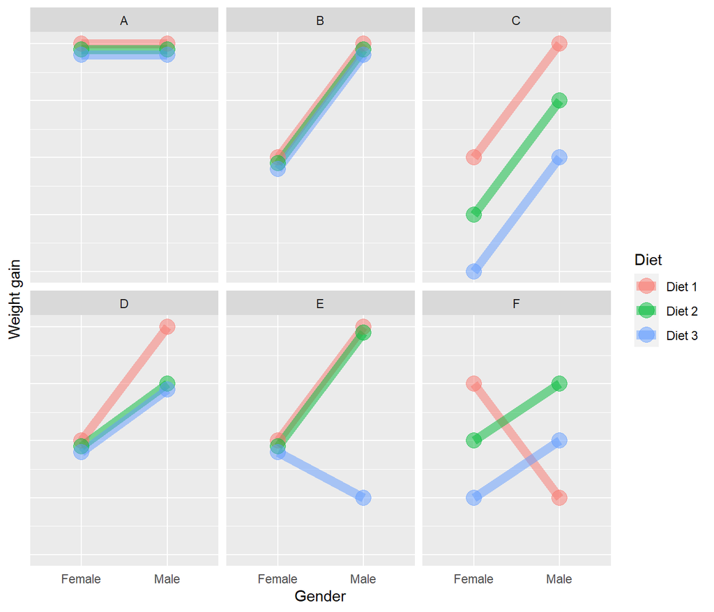

The concept of interaction

**A**

- No significant effect of diet,
- No significant effect of gender,
- No interaction

**B**

- No significant effect of diet,
- Effect of gender,
- No interaction

**C**

- Effect of diet,
- Effect of gender,
- No interaction

**D**

- Effect of diet in males
- No significant effect of diet in females,
- Effect of gender,
- Interaction (positive)

**E**

- Effect of diet in males,
- No significant effect of diet in females,
- Effect of gender,
- Interaction (negative)

**F**

- Effect of diet in male,
- Effect of diet in female,
- Effect of gender,
- Interaction (negative)

A data set which has two independent variable with of multiple levels. Suppose we have $K$ levels for independent variable 1 (columns) and $M$ categories for independent variable 2.

|  | Level 1 | Level 2 | … | Level $k$ | … | Level $K$ |
| --- | --- | --- | --- | --- | --- | --- |
| Category 1 | $x_{1,1,1}$ | $x_{1,2,1}$ | … | $x_{1,k,1}$ | … | $x_{1, K, 1}$ |
|  | $x_{1,1,2}$ | $x_{1,2,2}$ | … | $x_{1,k,2}$ | … | $x_{1,K,2}$ |
|  | … | … | … | … | … | … |
|  | $x_{1,1, j}$ | $x_{1,2, j}$ | … | $x_{1,k, j}$ | … | $x_{1,K,j}$ |
|  | … | … | … | … | … | … |
|  | $x_{1,1, J}$ | $x_{1,2, J}$ | … | $x_{1,k, J}$ | … | $x_{1,K,J}$ |
| Category 2 | $x_{2,1,1}$ | $x_{2,2,1}$ | … | $x_{2,k,1}$ | … | $x_{2, K, 1}$ |
|  | $x_{2,1,2}$ | $x_{2,2,2}$ | … | $x_{2,k,2}$ | … | $x_{2,K,2}$ |
|  | … | … | … | … | … | … |
|  | $x_{2,1, j}$ | $x_{2,2, j}$ | … | $x_{2,k, j}$ | … | $x_{2,K,j}$ |
|  | … | … | … | … | … | … |
|  | $x_{2,1, J}$ | $x_{2,2, J}$ | … | $x_{2,k, J}$ | … | $x_{2,K,J}$ |
| … | … | … | … | … | … | … |
| Category m | $x_{m,1,1}$ | $x_{m,2,1}$ | … | $x_{m,k,1}$ | … | $x_{m, K, 1}$ |
|  | $x_{m,1,2}$ | $x_{m,2,2}$ | … | $x_{m,k,2}$ | … | $x_{m,K,2}$ |
|  | … | … | … | … | … | … |
|  | $x_{m,1, j}$ | $x_{m,2, j}$ | … | $x_{m,k, j}$ | … | $x_{m,K,j}$ |
|  | … | … | … | … | … | … |
|  | $x_{m,1, J}$ | $x_{m,2, J}$ | … | $x_{m,k, J}$ | … | $x_{m,K,J}$ |
| … | … | … | … | … | … | … |
| Category M | $x_{M,1,1}$ | $x_{M,2,1}$ | … | $x_{M,k,1}$ | … | $x_{M, K, 1}$ |
|  | $x_{M,1,2}$ | $x_{M,2,2}$ | … | $x_{M,k,2}$ | … | $x_{M,K,2}$ |
|  | … | … | … | … | … | … |
|  | $x_{M,1, j}$ | $x_{M,2, j}$ | … | $x_{M,k, j}$ | … | $x_{M,K,j}$ |
|  | … | … | … | … | … | … |
|  | $x_{M,1, J}$ | $x_{M,2, J}$ | … | $x_{M,k, J}$ | … | $x_{M,K,J}$ |

The Entries of Two-Way ANOVA Table

| Source | $df$ | $SS$ | $MS$ | $F$ |
| --- | --- | --- | --- | --- |
| V1 (row) | $df_r = M-1$ | $SS_r = \sum_{m = 1}^{M} (\bar x_{m} - \bar x)^2$ | $MS_r = \frac{SS_r}{df_r}$ | $F_r = \frac{MS_r}{MS_W}$ |
| V2 (column) | $df_c = K - 1$ | $SS_c = \sum_{k = 1}^K (\bar x_k - \bar x)^2$ | $MS_c = \frac{SS_c}{df_c}$ | $F_c = \frac{MS_c}{MS_W}$ |
| Interaction | $df_I=df_r df_c$ | $SS_I = SS_B-SS_c-SS_r$ | $MS_I = \frac{SS_I}{df_I}$ | $F_I = \frac{MS_I}{MS_W}$ |
| Within samples | $df_W = MK(J-1)$ | $SS_W = \sum_{m=1}^{M} \sum_{k=1}^{K}(x_{m,k,j}-\bar x_{m,k})^2$ | $MS_W = \frac{SS_W}{df_W}$ |  |
| Between samples | $df_B = MK - 1$ | $SS_B = J\sum_{m = 1}^M \sum_{k=1}^{K}(\bar x_{m,k} - \bar x)^2$ | $MS_B = \frac {SS_B}{df_B}$ |  |
| Total | $df_T = MKJ - 1$ | $SS_T = \sum(x-\bar x) ^2$ | $MS_T = \frac{SS_T}{df_T}$ |  |

*Action*: Fill in the ANOVA table on the basis of the following data and draw your conclusion (15 minutes).

The ANOVA table for the weight gain experiment

| Source | $df$ | $SS$ | $MS$ | $F$ |
| --- | --- | --- | --- | --- |
| V1 (row) |  |  |  |  |
| V2 (column) |  |  |  |  |
| Interaction |  |  |  |  |
| Within samples |  |  |  |  |
| Between samples |  |  |  |  |
| Total |  |  |  |  |

**Click to see the results**

```r
dtf <- data.frame(
  w = c(90,95,100,75,78,90,120,125,130,100,118,112,125,130,135,118,125,132),
  diet = rep(c("Diet1", "Diet2", "Diet3"), each = 6),
  gender = rep(c("Male", "Female"), each = 3)
)

# df
(M <- nlevels(as.factor(dtf$gender)))
```

```
[1] 2
```

```r
(K <- nlevels(as.factor(dtf$diet)))
```

```
[1] 3
```

```r
(n <- nrow(dtf))
```

```
[1] 18
```

```r
(J <- n / M / K)
```

```
[1] 3
```

```r
(dfr <- M - 1)
```

```
[1] 1
```

```r
(dfc <- K - 1)
```

```
[1] 2
```

```r
(dfI <- dfr * dfc)
```

```
[1] 2
```

```r
(dfW <- M * K * ( J - 1))
```

```
[1] 12
```

```r
(dfB <- M * K - 1)
```

```
[1] 5
```

```r
(dfT <- n - 1)
```

```
[1] 17
```

```r
# mean
(xbar <- mean(dtf$w))
```

```
[1] 111
```

```r
(xmk_bar <- tapply(dtf$w, list(dtf$diet, dtf$gender), mean))
```

```
      Female Male
Diet1     81   95
Diet2    110  125
Diet3    125  130
```

```r
dtf$xmk_bar <- mapply(function(d, g) xmk_bar[d, g], dtf$diet, dtf$gender)
(xm_bar <- colMeans(xmk_bar))
```

```
  Female     Male
105.3333 116.6667
```

```r
(xk_bar <- rowMeans(xmk_bar))
```

```
Diet1 Diet2 Diet3
 88.0 117.5 127.5
```

```r
# SS
(SSB <- J * sum((xmk_bar - xbar) ^ 2))
```

```
[1] 5730
```

```r
(SSW <- sum((dtf$w - dtf$xmk_bar) ^2))
```

```
[1] 542
```

```r
(SST <- sum((dtf$w - xbar) ^ 2))
```

```
[1] 6272
```

```r
(SSr <- K * J * sum((xm_bar - xbar) ^2))
```

```
[1] 578
```

```r
(SSc <- M * J * sum((xk_bar - xbar) ^ 2))
```

```
[1] 5061
```

```r
(SSI <- SSB - SSc - SSr)
```

```
[1] 91
```

```r
(SSS <- k * sum((xjbar - xbar) ^ 2))
```

```
[1] 245874.8
```

```r
(SSWccor <- SSW-SSS)
```

```
[1] -245332.8
```

```r
# Double check
SSW + SSB
```

```
[1] 6272
```

```r
SST
```

```
[1] 6272
```

```r
# MS
(MSr <- SSr / dfr)
```

```
[1] 578
```

```r
(MSc <- SSc / dfc)
```

```
[1] 2530.5
```

```r
(MSI <- SSI / dfI)
```

```
[1] 45.5
```

```r
(MSW <- SSW / dfW)
```

```
[1] 45.16667
```

```r
# F
(F_r <- MSr / MSW)
```

```
[1] 12.79705
```

```r
qf(0.95, df1 = dfr, df2 = dfW)
```

```
[1] 4.747225
```

```r
pf(F_r, df1 = dfr, df2 = dfW, lower.tail = FALSE)
```

```
[1] 0.0038011
```

```r
(F_c <- MSc / MSW)
```

```
[1] 56.02583
```

```r
qf(0.95, df1 = dfc, df2 = dfW)
```

```
[1] 3.885294
```

```r
pf(F_c, df1 = dfc, df2 = dfW, lower.tail = FALSE)
```

```
[1] 8.193548e-07
```

```r
(F_I <- MSI / MSW)
```

```
[1] 1.00738
```

```r
qf(0.95, df1 = dfI, df2 = dfW)
```

```
[1] 3.885294
```

```r
pf(F_I, df1 = dfI, df2 = dfW, lower.tail = FALSE)
```

```
[1] 0.3940701
```

The ANOVA table for the weight gain experiment

[output not shown]

Conclusion:

Both diet and gender have a significant effect on the weight gain of rats, and there is no significant interaction between gender and diet in weight gain.

One-step:

```r
aov_wg <- aov(w ~ diet * gender, data = dtf)
summary(aov_wg)
```

```
            Df Sum Sq Mean Sq F value   Pr(>F)
diet         2   5061  2530.5  56.026 8.19e-07 ***
gender       1    578   578.0  12.797   0.0038 **
diet:gender  2     91    45.5   1.007   0.3941
Residuals   12    542    45.2
---
Signif. codes:  0 '***' 0.001 '**' 0.01 '*' 0.05 '.' 0.1 ' ' 1
```

# 7 Readings

- The R Book - Chapter 11

# 8 Highlights

- Carry out a step-by-step one-way ANOVA (repeated or not repeated) for a scientific question.
  - State $H_0$ and $H_1$.
  - Calculate the critical value for a given $\alpha$.
  - Calculate the testing statistics ($F$ score).
  - Draw a conclusion for the scientific question.